# Chapter 8 Problems

## Chapter Exercises

### Exercise 8.37

1. A correlation coefficient of -0.90 indicates a stronger linear relationship than a correlation of 0.5.
2. Correlation is a measure of the association between any two variables.

Answer: a) **TRUE.** This is because when comparing the strengths of linear relationships, or R, we focus on the magnitude |R|. The sign is only there to describe the direction of the relationship (postive upward or negative downward). Thus |-0.90| > |0.50| b) **FALSE.** A correlation is the strength of a linear relationship between two variables. Two variables can be strongly assosciated in some way but have a very weak linear relationship.

### Exercise 8.39

Hypotheses tests: $H_0: \beta_1 = 1$ $H_A: \beta_1 \neq 1$

```r
# use given info
SE = 0.0259
b1 = 0.9112
b1_null = 1
deg_f = 170 - 2
```

```r
# ... and find p_value base on t_value
(t_stat = (b1 - b1_null) / SE)
```

```
## [1] -3.428571
```

```r
pt(q = t_stat, df = deg_f)
```

```
## [1] 0.0003816325
```

with an extremely low p-value (~0.0003), there is strong evidence to sugest that age difference between husbands and wives is NOT consistent across all ages, that is $H_A: \beta_1 \neq 1$.

2. Write eqn: $\hat{age_w} = 1.5740 + 0.91112 \cdot age_m$
3. Interpret slope and intercept

```r
# slope: for each additional year in age_h, the wife's age is expected to grow by 0.9112 on average
# intercept: For men age 0 years, they expect to have a wife with an average age of 1.5740. Not meanignful.
```

4. Given $R^2 = 0.88$, what is $R$?

```r
sqrt(0.88)
```

```
## [1] 0.9380832
```

5. You meet a married man from Britain who is 55 years old. What would you predict his wife’s age to be? How reliable is this prediction?

```r
b0 = 1.5740
b1 = 0.9112
age_h = 55
age_w_hat <- function(age){b0 + b1 * age}
# we are fairly confident this is a good estimate since R^2, the strength of our model fitting the data, is relativley high (88%)
age_w_hat(age_h)
```

```
## [1] 51.69
```

### Exercise 8.41

Exercise 8.22 introduced a data set on nutrition information on Starbucks food menu items. Based on the scatterplot and the residual plot provided, describe the relationship between the protein content and calories of these menu items, and determine if a simple linear model is appropriate to predict amount of protein from the number of calories.

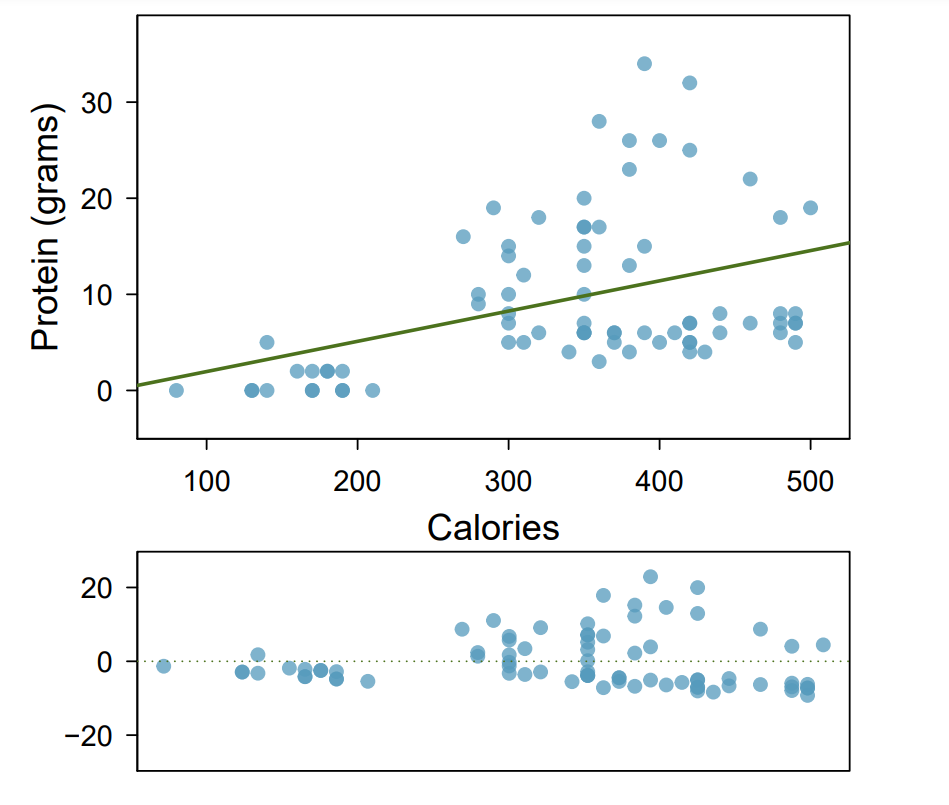